### Initial Setup

```python
import getpass
import os
import warnings
warnings.filterwarnings("ignore")
from datetime import datetime
from pathlib import Path
from urllib.parse import quote_plus
import math
import sys


import matplotlib.pyplot as plt
plt.rc('axes', axisbelow=True)  # sets grid under plot
plt.rcParams.update({'font.size': 16})
import matplotlib.cm as cm
import numpy as np
import pandas as pd
from dotenv import load_dotenv
from pymongo import MongoClient
import pickle

from sklearn.feature_selection import chi2
from sklearn.metrics import confusion_matrix, f1_score, plot_roc_curve, accuracy_score, precision_recall_fscore_support
from sklearn.preprocessing import MinMaxScaler
from sklearn.model_selection import train_test_split, cross_validate, KFold
from sklearn.ensemble import RandomForestClassifier, AdaBoostClassifier
from sklearn.tree import DecisionTreeClassifier
from sklearn.svm import LinearSVC, SVC
from sklearn.decomposition import FactorAnalysis
from scipy.cluster.hierarchy import dendrogram, linkage
from sklearn.cluster import AgglomerativeClustering
from sklearn.metrics import silhouette_score
from sklearn.cluster import KMeans, MiniBatchKMeans, DBSCAN
# fill missing data
from sklearn.experimental import enable_iterative_imputer
from sklearn.impute import IterativeImputer

# warnings.filterwarnings("ignore")

base_imgs_path = Path().resolve()\
    .parent\
    .joinpath("outputs")

grant_result_imgs_path = base_imgs_path\
    .joinpath('grantResult')\
    .resolve()

predictions_path = grant_result_imgs_path.joinpath('prediction').resolve()

profiles_imgs_path = grant_result_imgs_path.joinpath('profiles').resolve()

saves_path =  grant_result_imgs_path.joinpath('saves').resolve()

dotenv_path = Path().resolve().joinpath('.env')
load_dotenv(dotenv_path)
mongo_user = os.environ.get("MONGO_USER")
mongo_password = os.environ.get("MONGO_PWD")
mongo_host = os.environ.get("MONGO_HOST")

if not mongo_user or not mongo_password:
    print("Mongo user not found in MONGO_USER and MONGO_PWD environment variables...")
    mongo_user = input('Insert mongo user: ')
    mongo_password = getpass.getpass('Insert mongo user password: ')

if not mongo_host:
    mongo_host = input("Insert mongo host: [localhost:27017] ") or "localhost:27017"

mongo_uri = "mongodb://%s:%s@%s" % (quote_plus(mongo_user), quote_plus(mongo_password), mongo_host)

# print(mongo_uri)
client = MongoClient(mongo_uri)
db = client.cop_mode_export

def clean_permission_feature_names(feature):
    if "permission" in feature:
        return "permission_" + feature.split('.')[-1]
    return feature

def _get_original_data(db,
                       drop_features,
                       verbose=True):
    # removed 'isKeyguardLocked' and 'screenIsInteractive' because CM-NPM now only asks if screen is interactive
    # removed dockState because we have no record where it is different than 0
    # removed checkPermission because Android's permission manager operates at the group level
    original_data = pd.DataFrame(db.data.aggregate([
        {"$match": {"permissionDialogData.answerType": "USER_ANSWERED"}},
        {"$project": {"_id": 0,
                      "timestamp": "$permissionDialogData.timestamp",
                      "callState": "$contextData.callState",
                      # "dockState": "$contextData.dockState",
                      # "isKeyguardLocked": "$contextData.isKeyguardLocked",
                      # "screenIsInteractive": "$contextData.screenIsInteractive",
                      "networkStatus": "$contextData.networkStatus",
                      "plugState": "$contextData.plugState",
                      # "checkedPermission": "$permissionDialogData.checkedPermission",
                      "checkedPermissionGroup": "$permissionDialogData.checkedPermissionGroup",
                      "grantResult": "$permissionDialogData.grantResult",
                      "selectedSemanticLoc": "$permissionDialogData.selectedSemanticLoc",
                      "wasRequestExpected": "$permissionDialogData.wasRequestExpected",
                      "category": "$permissionDialogData.requestingApplicationInfo.category",
                      "userID": 1,
                      "foregroundRunningApplicationInfoArray": "$contextData.foregroundRunningApplicationInfoArray",
                      "topRunningApplicationPackageName": "$contextData.topRunningApplicationInfo.packageName",
                      "requestingApplicationPackageName": "$permissionDialogData.requestingApplicationInfo.packageName",
                      "isInEvent": "$contextData.isInEvent",
                      "isTopAppRequestingApp": "$contextData.isTopAppRequestingApp",
                      "isForeground": "$permissionDialogData.requestingApplicationInfo.isForeground",
                      }
         }
    ]))
    # display(len(original_data))

    if verbose:
        nr_running_apps_missing_docs = db.data.find(
            {"permissionDialogData.answerType": "USER_ANSWERED",
             "$or": [{"contextData.foregroundRunningApplicationInfoArray": None},
                     {"contextData.topRunningApplicationInfo": None}]},
            {"permissionDialogData": 1,
             "contextData.foregroundRunningApplicationInfoArray": 1,
             "contextData.topRunningApplicationInfo.packageName": 1}).count()

        print(f"We are missing information about the running and top apps on {nr_running_apps_missing_docs} records")

    original_data.drop(["foregroundRunningApplicationInfoArray",
                        "topRunningApplicationPackageName"], axis=1, inplace=True)

    datetime_col = [datetime.fromtimestamp(x / 1000) for x in
                    original_data["timestamp"]]
    original_data["hour"] = [date.hour for date in datetime_col]
    original_data["isWeekend"] = [(date.weekday() >= 5) for date in
                                  datetime_col]
    # display(original_data)

    if verbose:
        nr_requests_in_event = original_data['isInEvent'].loc[original_data['isInEvent'] == 1].count()
        print(f"Requests where the user is in event: "
              f"{nr_requests_in_event} ({round(nr_requests_in_event / len(original_data) * 100, 2)}%)")

    original_data = original_data.loc[:,
                    [column for column in original_data.columns
                     if column not in drop_features]]
    if verbose:
        print("Full dataset features: \n\t - {}.".format('.\n\t - '.join(original_data.columns)))

    return original_data


def _get_encoded_scaled_x_y(original_data, y_feature, verbose=True):
    X_one_hot_enc = pd.get_dummies(original_data)
    # print(X_one_hot_enc.columns)

    nr_requests_before_dropping_na = len(X_one_hot_enc)
    X_one_hot_enc.dropna(inplace=True)  # some isForeground are nan

    if (verbose):
        print(
            f"\nDropped {nr_requests_before_dropping_na - len(X_one_hot_enc)} requests due to nan features")
        if y_feature == 'wasRequestExpected':
            was_request_expected_df = X_one_hot_enc[
                'wasRequestExpected'].replace(
                {0: "UNKNOWN", 1: "UNEXPECTED", 2: "EXPECTED"}).value_counts()
            was_request_expected_df = pd.DataFrame({
                'count': was_request_expected_df,
                'relative_count': round(
                    was_request_expected_df / was_request_expected_df.sum() * 100,
                    2)
            })
            print(was_request_expected_df)

    if y_feature == 'wasRequestExpected':
        nr_requests_before_dropping_unknown = len(X_one_hot_enc)
        X_one_hot_enc = X_one_hot_enc.loc[X_one_hot_enc['wasRequestExpected'] != 0]

        if verbose:
            print(
                f"Dropped {nr_requests_before_dropping_unknown - len(X_one_hot_enc)} requests where wasRequestExpected==UNKNOWN")
            print(
                f"Remaining requests: {len(X_one_hot_enc)} ({round(len(X_one_hot_enc) / nr_requests_before_dropping_na * 100, 2)}%)")

    scaler = MinMaxScaler()
    X_one_hot_enc = pd.DataFrame(scaler.fit_transform(X_one_hot_enc),
                                 columns=X_one_hot_enc.columns)

    X_col_idx = (X_one_hot_enc.columns != y_feature)
    if y_feature == "wasRequestExpected":
        # we wouldn't have the grant result when predicting expectancy
        X_col_idx = np.logical_and(X_col_idx, (X_one_hot_enc.columns != "grantResult"))

    X, y = X_one_hot_enc.loc[:, X_col_idx], X_one_hot_enc[y_feature]

    if verbose:
        print("Features: \n\t - {}.".format('.\n\t - '.join(X.columns)))
    return X, y
```

# Dataset Characterization

Number of users

```python
len(db.data.distinct("userID"))
```

```
93
```

#### Total number of requests

```python
nr_total_requests = db.data.count_documents({})
print(nr_total_requests)
```

```
2180302
```

#### Distribution of answer type

```python
data = pd.DataFrame(db.data.aggregate([
    # { "$match": { "permissionDialogData.answerType": "USER_ANSWERED" } },
    { "$group": { "_id": "$permissionDialogData.answerType", "count": {"$sum": 1}} },
    { "$sort": {"count": 1}}
]))
display(data)
```

|  | _id | count |
| --- | --- | --- |
| 0 | DISMISSED | 1108 |
| 1 | USER_ANSWERED | 65261 |
| 2 | TIMEDOUT | 74116 |
| 3 | UNHANDLED | 96834 |
| 4 | CACHE_ANSWERED | 1942983 |

#### Answers per user

```python
data = pd.DataFrame(db.data.aggregate([
    { "$match": { "permissionDialogData.answerType": "USER_ANSWERED" } },
    { "$group": { "_id": "$userID", "count": {"$sum": 1}} },
    { "$sort": {"count": 1}}
]))
# with pd.option_context('display.max_rows', None):
#     print(data)
# data.boxplot(column='count')
print(data['count'].describe())
```

```
count      93.000000
mean      701.731183
std      1096.330115
min        51.000000
25%       270.000000
50%       446.000000
75%       680.000000
max      8358.000000
Name: count, dtype: float64
```

# Privacy Profiles

## Privacy Profiles using the category-permission pair

This methodology follows the approach described in Liu, B., Andersen, M. S., Schaub, F., Almuhimedi, H., Zhang, S. A., Sadeh, N., ... & Acquisti, A. (2016). Follow my recommendations: A personalized privacy assistant for mobile app permissions. In Twelfth Symposium on Usable Privacy and Security (SOUPS 2016) (pp. 27-41).

#### Load the data

```python
data = _get_original_data(db,
                          drop_features=("timestamp",
                                         "requestingApplicationPackageName"),
                          verbose=True)

# Put all games in same category
data['category'] = data['category'].apply(lambda x: x.split('_')[0] if x.startswith('GAME_') else x)

# Clean permission names
data['checkedPermissionGroup'] = data['checkedPermissionGroup'].map(lambda x: x.split('.')[-1])
data = data.rename(columns={'checkedPermissionGroup': 'permission'})
data = data.loc[data['permission'] != 'SENSORS']  # remove SENSORS permissions -- only 1 permission
```

```
We are missing information about the running and top apps on 4448 records
Requests where the user is in event: 7655 (11.73%)
Full dataset features:
	 - userID.
	 - callState.
	 - networkStatus.
	 - plugState.
	 - checkedPermissionGroup.
	 - grantResult.
	 - selectedSemanticLoc.
	 - wasRequestExpected.
	 - category.
	 - isTopAppRequestingApp.
	 - isForeground.
	 - isInEvent.
	 - hour.
	 - isWeekend.
```

#### Form the tensor data

Each user becomes a row where each column is a pair category-permission, whose value is the average grant result of the user (value between -1 and 0) for that specific pair.

Missing values correspond to cases where the user has no answered permission for the given pair. Data must be inputted in order to form the profiles using hierarchical clustering. We use SciKit's [IterativeImputer](https://scikit-learn.org/stable/modules/impute.html#iterative-imputer).

```python
def _get_tensor_data(data, clustering_features, y_feature, random_state):
    clustering_features_unique_tuples = data[clustering_features].drop_duplicates()

    clustering_df = data.groupby(['userID'] + clustering_features).mean([y_feature])
    clustering_df = clustering_df[[y_feature]]
    # print(clustering_df)

    all_users = data['userID'].unique()
    for u_index, u in enumerate(all_users):
        for i, row in clustering_features_unique_tuples.iterrows():
            try:
                index = tuple([u] + row.to_list())
                clustering_df.loc[index][y_feature]
            except KeyError:
                clustering_df.loc[index, y_feature] = np.nan
    clustering_df = clustering_df.reset_index()

    # print(clustering_df)
    missing_data_count = clustering_df[y_feature].isna().sum()
    all_data_count = len(clustering_df)
    print(f"Percentage of missing data for dataset with feature {clustering_features} is: {round(missing_data_count / all_data_count * 100, 2)}.")

    imp_mean = IterativeImputer(random_state=random_state)
    imp_full_clustering_dataset_enc = pd.DataFrame(
        # IMP: get_dummies puts all encoded columns at the end, but keeps continuous at start
        # So, we put the y_feature first so that the index is 0
        imp_mean.fit_transform(pd.get_dummies(clustering_df[[y_feature] + clustering_features])))

    y_feature_index = 0
    clustering_df[y_feature] = imp_full_clustering_dataset_enc.loc[:, y_feature_index]
    # print(clustering_df)

    clustering_df = clustering_df.set_index(['userID'] + clustering_features)
    col_names = []
    tensor_data = []
    for u_index, u in enumerate(all_users):
        user_data = []
        # print(data.loc[u])
        for i, row in clustering_features_unique_tuples.iterrows():
            if u_index == 0:
                col_names.append('|'.join(row.astype('str')))

            # no empty data
            index = tuple([u] + row.to_list())
            value = clustering_df.loc[index][0]
            user_data.append(value)
        # print(user_data)
        tensor_data.append(user_data)

    tensor_data = pd.DataFrame(tensor_data, index=all_users, columns=col_names)
    # print(tensor_data)
    return tensor_data

clustering_features = ['category', 'permission']
y_feature = 'grantResult'
random_state = 42
tensor_data = _get_tensor_data(data, clustering_features, y_feature, random_state)
```

```
Percentage of missing data for dataset with feature ['category', 'permission'] is: 79.55.
```

##### Dendogram

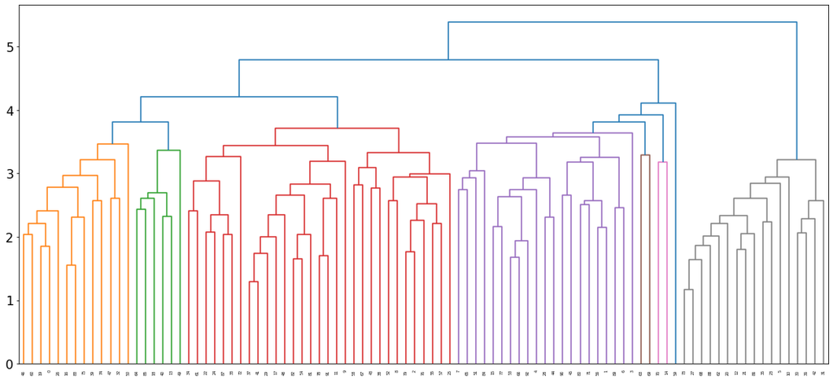

```python
linked = linkage(tensor_data, "complete", optimal_ordering=True)
plt.figure(figsize=(15, 7))
dendrogram(linked, orientation="top", distance_sort="descending", show_leaf_counts=True)
plt.tight_layout()
plt.show()
```

From the dendogram, we can select where to perform the "cut" to have the privacy profiles.

For an illustrative example, we will select 3 profiles and plot them.

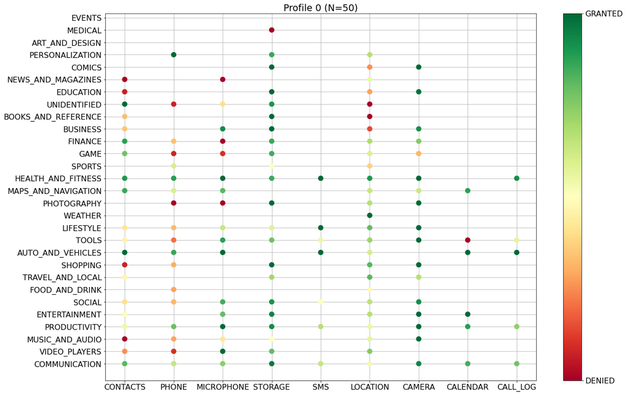

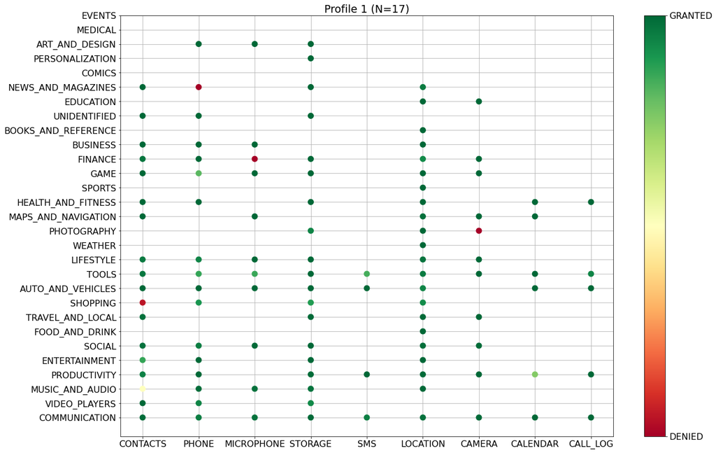

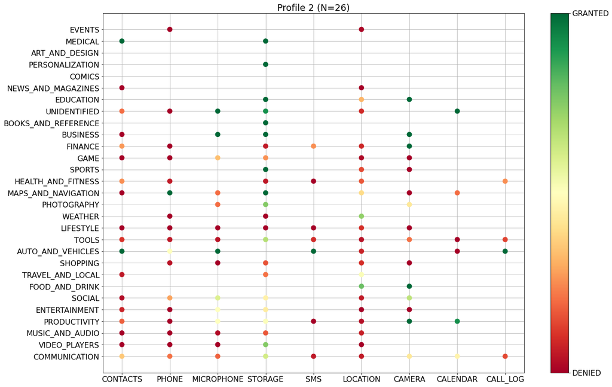

```python
cluster = AgglomerativeClustering(n_clusters=3, affinity="euclidean", linkage="complete")
cluster.fit_predict(tensor_data)
labels_dict = {userID: label for userID, label in
               zip(tensor_data.index, cluster.labels_)}
data["hc_label"] = [labels_dict[userID] for userID in data["userID"]]
# tensor_dataset["hc_label"] = cluster.labels_
permissions = list(data["permission"].unique())
perm_ticks_map = {tick: i for i, tick in enumerate(permissions)}
categories = list(data["category"].unique())
cat_ticks_map = {tick: i for i, tick in enumerate(categories)}

# cmap = plt.cm.get_cmap("RdYlGn")
for c in list(set(cluster.labels_)):
    plot_data = data.loc[data["hc_label"] == c, :].groupby(clustering_features).mean()
    plot_data.reset_index(inplace=True)
    fig = plt.figure(figsize=(20, 14))  # TODO: fix size
    ax = fig.add_subplot()
    x = [perm_ticks_map[perm] for perm in plot_data["permission"]]
    y = [cat_ticks_map[cat] for cat in plot_data["category"]]
    scatter_plot = ax.scatter(x, y,
        c=plot_data[y_feature], cmap="RdYlGn",
        s=100)  # , s=100
    ax.set_xticks(range(len(permissions)))
    ax.set_xticklabels(permissions)
    ax.set_yticks(range(len(categories)))
    ax.set_yticklabels(categories)

    nr_users_in_c = len(data.loc[data["hc_label"] == c, "userID"].unique())
    ax.set_title(f"Profile {c} (N={nr_users_in_c})")
    ax.grid()
    cbar = fig.colorbar(scatter_plot, ticks=[-1, 0])
    cbar.ax.set_yticklabels(['DENIED', 'GRANTED'])
```

From the plots above, we can see that participants in profile 1 (17 participants) allow most requests, therefore these are typically referred to as "The unconcerned". In contrast, participants in profile 2 (26 participants) mostly deny permission requests. These are the "Privacy Conscious". However, most participants are in profile 0, where there seems to bee a more diverse response. Potentially, this profile could have been further divided, by increasing the number of clusters. Note that increasing the number of clusters degrades the interpretability, but might allow for a better separation of behaviors.

## n-Dimensional Privacy Profiles

The previous profiles were built using just the category-permission pair. However, we can use other features and even more features, such as contextual features, to form the profiles.

Below we follow the same methodology to build profiles with the category-permission-expectancy tuples. Just note that an increase on the number of considered features leads to an increase in the amount of missing data.

```python
data = _get_original_data(db,
                          drop_features=("timestamp",
                                         "requestingApplicationPackageName"),
                          verbose=False)

# Put all games in same category
data['category'] = data['category'].apply(lambda x: x.split('_')[0] if x.startswith('GAME_') else x)

# Clean permission names
data['checkedPermissionGroup'] = data['checkedPermissionGroup'].map(lambda x: x.split('.')[-1])
data = data.rename(columns={'checkedPermissionGroup': 'permission'})
data = data.loc[data['permission'] != 'SENSORS']  # remove SENSORS permissions -- only 1 permission

# Remove requests with wasRequestExpected == UNKNOWN
data = data.loc[data['wasRequestExpected'] != 0]
data['wasRequestExpected'] = data['wasRequestExpected'].replace({1: "UNEXPECTED", 2: "EXPECTED"})

clustering_features = ['category', 'permission', 'wasRequestExpected']
y_feature = 'grantResult'
random_state = 42
tensor_data = _get_tensor_data(data, clustering_features, y_feature, random_state)
```

```
Percentage of missing data for dataset with feature ['category', 'permission', 'wasRequestExpected'] is: 84.03.
```

##### Dendogram

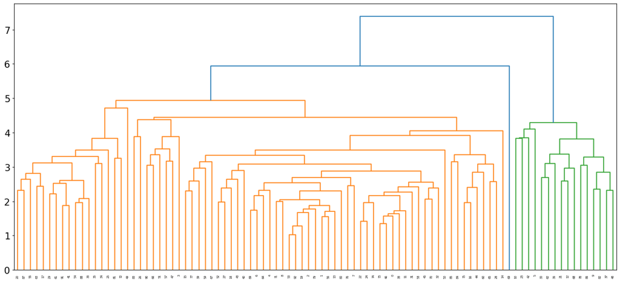

```python
linked = linkage(tensor_data, "complete", optimal_ordering=True)
plt.figure(figsize=(15, 7))
dendrogram(linked, orientation="top", distance_sort="descending", show_leaf_counts=True)
plt.tight_layout()
```

Notice the difference between this dendogram and the previous example. In this case 2 or 3 profiles should result in the best clustering. For an illustrative example we select 3 again.

##### 3 category-permission-expectancy Profiles

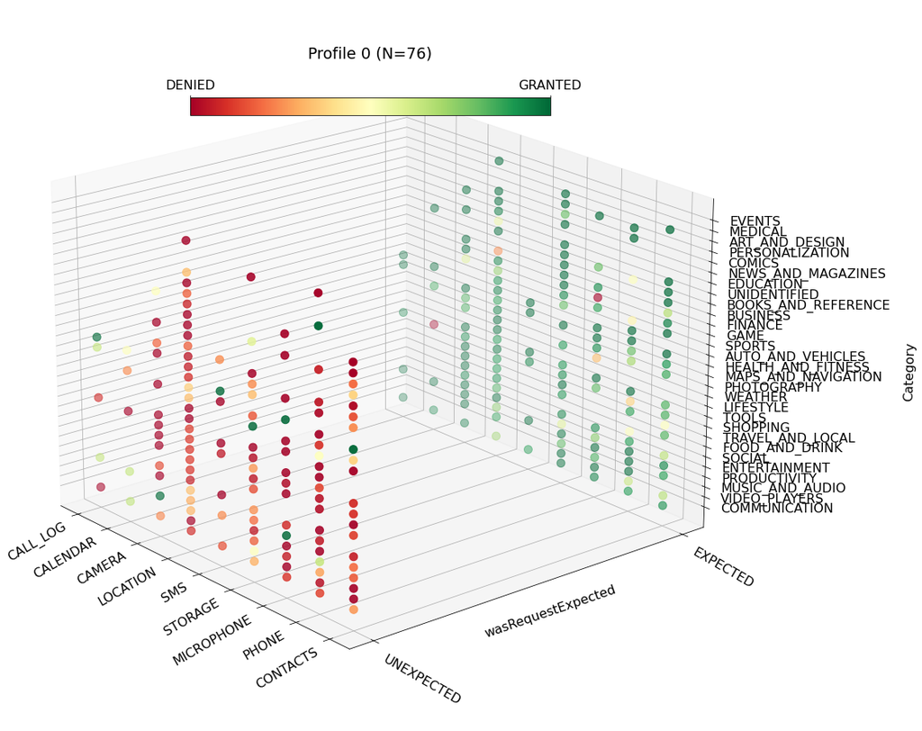

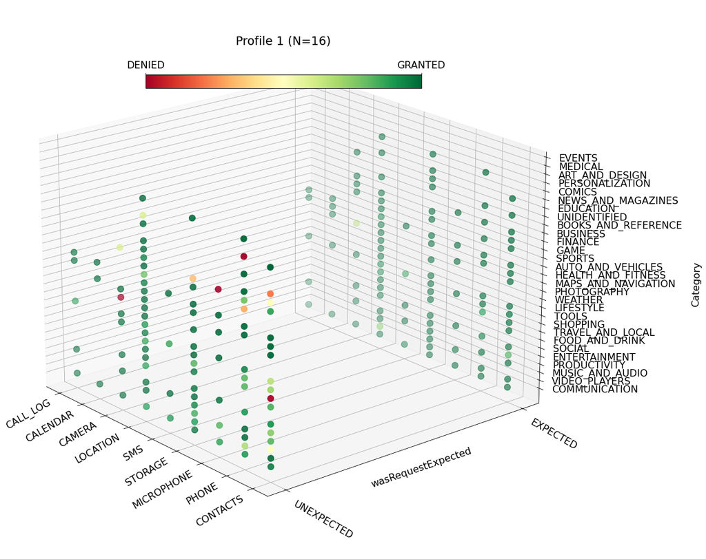

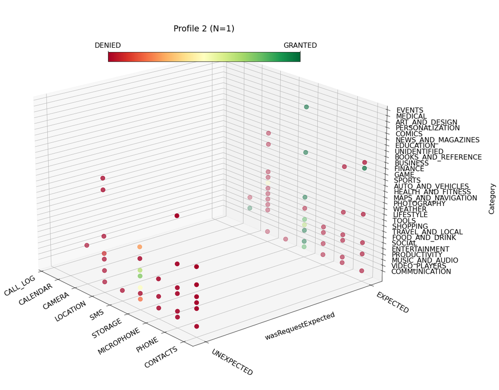

```python
cluster = AgglomerativeClustering(n_clusters=3, affinity="euclidean", linkage="complete")
cluster.fit_predict(tensor_data)
labels_dict = {userID: label for userID, label in
               zip(tensor_data.index, cluster.labels_)}
data["hc_label"] = [labels_dict[userID] for userID in data["userID"]]
# tensor_dataset["hc_label"] = cluster.labels_
permissions = list(data["permission"].unique())
perm_ticks_map = {tick: i for i, tick in enumerate(permissions)}
categories = list(data["category"].unique())
cat_ticks_map = {tick: i for i, tick in enumerate(categories)}

for c in list(set(cluster.labels_)):
    plot_data = data.loc[data["hc_label"] == c, :].groupby(clustering_features).mean()
    plot_data.reset_index(inplace=True)
    fig = plt.figure(figsize=(16, 25))
    ax = fig.add_subplot(projection='3d')
    third_feature_unique_values = list(plot_data[clustering_features[-1]].unique())
    third_feature_ticks_map = {tick: i for i, tick in enumerate(third_feature_unique_values)}
    scatter_plot = ax.scatter(
        [perm_ticks_map[perm] for perm in plot_data["permission"]],
        [third_feature_ticks_map[value] for value in plot_data[clustering_features[-1]]],
        [cat_ticks_map[cat] for cat in plot_data["category"]],
        c=plot_data[y_feature], cmap="RdYlGn",
        s=100)  # , s=100

    ax.set_yticks(range(len(third_feature_unique_values)))
    # ax.set_yticklabels(map(str, third_feature_unique_values))
    ax.set_ylabel(clustering_features[-1])
    ax.set_yticklabels(third_feature_unique_values,
                       rotation=-30,
                       fontdict={'horizontalalignment': 'left',
                                 'verticalalignment': 'top'})

    ax.set_xticks(range(len(permissions)))
    ax.set_xticklabels(permissions, rotation=30,
                       fontdict={
                           'horizontalalignment': 'right',
                           'verticalalignment': 'center_baseline'})
    ax.set_zlabel('Category', labelpad=120)
    ax.set_zticks(range(len(categories)))
    ax.set_zticklabels(categories,
                       fontdict={'horizontalalignment': 'left',
                                 'verticalalignment': 'center_baseline'})
    ax.view_init(20, 140)

    nr_users_in_c = len(data.loc[data["hc_label"] == c, "userID"].unique())
    ax.set_title(f"Profile {c} (N={nr_users_in_c})", y=1.0)

    # cbar = fig.colorbar(cm.ScalarMappable(cmap='RdYlGn'), ax=ax, ticks=[-1, 0], shrink=0.2, pad=.3)
    cbar = fig.colorbar(scatter_plot, ticks=[-1, 0], pad=-0.1, shrink=0.5, location='top')
    cbar.ax.set_xticklabels(['DENIED', 'GRANTED'])
    plt.tight_layout()
```

Looking at the above plots, profile 0, which has 76 (81.7%) participants corresponds to participants that deny almost all unexpected requests, while allowing almost all expected requests. These are participants whose privacy behavior is strongly motivated by their expectations. In contrast, profile 1 (16 participants) corresponds to participants that allow most requests regardless of their expectancy. Profile 2 belongs to a single user that denies most requests.

With the profiles formed, you can then use those labels (`data["hc_label"]`) as features towards training a classifier to predict the grant result.

We currently working on publishing a paper on such results and will then provide the respective code and results. However, you can already do it if you have access to the dataset.